# DATA 643 Proj 1

Dan Fanelli

June 5, 2017

# Global Baseline Predictors and RMSE

[figure not shown]

## LastFM Users and Artists: Listen Counts

LastFM provides a data set that gives us counts of how many times a LastFM user has listened to a particular artist. This system should recommend musical artists to users.

We will assume that a user’s “listen count” per artist is analogous to an explicit “rating” of the artist

We well exclude listen counts above 1000 for the sake of visualizing the data and avoiding skew via huge listen counts. (Maybe listen counts above 5000 are “bots” or invalid in some other way)

A Sample of the Initial Data

|  | userID | artistID | artist | listen_count |
| --- | --- | --- | --- | --- |
| 72678 | 743 | 5575 | SS501 | 1244 |
| 5132 | 2055 | 157 | Michael Jackson | 301 |
| 6004 | 499 | 172 | Garbage | 2 |
| 90035 | 1891 | 17450 | Sloe Texture | 27 |
| 6579 | 1279 | 182 | Keane | 37 |
| 89857 | 1866 | 17237 | Stephen King | 214 |
| 66961 | 767 | 3877 | Pink Martini | 126 |
| 41124 | 1163 | 998 | Orchestral Manoeuvres in the Dark | 3 |
| 7172 | 1128 | 190 | Muse | 157 |
| 5315 | 1505 | 159 | The Cure | 267 |

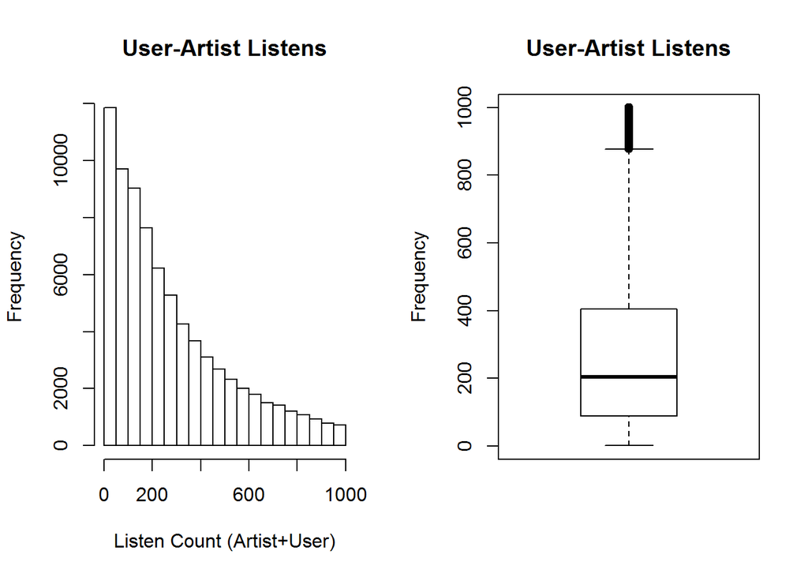

### The Raw average of ALL user-item combination = 278.2

### Calculate the RMSE for raw average for both your training data and your test data.

RMSE for Raw Avg:

```
## RMSE (TRAIN) 2.69
```

```
## RMSE (TEST) 5.31
```

### Using your training data, calculate the bias for each user and each item

#### USER BIAS (TRAIN)

```
##   userMean userID user_bias
## 1   167.80      3   -110.40
## 2   381.75      4    103.55
## 3   201.50      5    -76.70
## 4    21.25      6   -256.95
## 5   677.50      7    399.30
## 6   860.50      8    582.30
```

#### ARTIST BIAS (TRAIN)

```
##   artistMean artistID artist_bias
## 1   385.0000        2    106.8000
## 2   205.0000        6    -73.2000
## 3   146.6667        7   -131.5333
## 4   587.0000        8    308.8000
## 5    49.0000        9   -229.2000
## 6   154.0000       12   -124.2000
```

#### USER BIAS (TEST)

```
##   userMean userID user_bias
## 1 102.3333      3 -175.8667
## 2 389.0000      4  110.8000
## 3  14.0000      6 -264.2000
## 4 581.0000      8  302.8000
## 5 729.0000      9  450.8000
## 6 761.0000     10  482.8000
```

#### ARTIST BIAS (TEST)

```
##   artistMean artistID artist_bias
## 1        212        7       -66.2
## 2        866        9       587.8
## 3         42       12      -236.2
## 4        136       19      -142.2
## 5        183       23       -95.2
## 6        477       30       198.8
```

### From the raw average, and the appropriate user and item biases, calculate the baseline predictors for every user-item combination.

Train Data Predictions

|  | userID | artistID | artist | listen_count | listen_count_PREDICTION |
| --- | --- | --- | --- | --- | --- |
| 5132 | 2055 | 157 | Michael Jackson | 301 | 333.8132 |
| 6004 | 499 | 172 | Garbage | 2 | 0.0000 |
| 90035 | 1891 | 17450 | Sloe Texture | 27 | 0.0000 |
| 6579 | 1279 | 182 | Keane | 37 | 40.0500 |
| 89857 | 1866 | 17237 | Stephen King | 214 | 309.9429 |
| 66961 | 767 | 3877 | Pink Martini | 126 | 39.3000 |

Test Data Predictions

|  | userID | artistID | artist | listen_count | listen_count_PREDICTION |
| --- | --- | --- | --- | --- | --- |
| 86423 | 2100 | 13677 | Moëvöt | 278 | 529.8000 |
| 33615 | 26 | 707 | Metallica | 278 | 251.9429 |
| 28210 | 1433 | 530 | Alphabeat | 460 | 494.3000 |
| 27934 | 13 | 526 | La Roux | 6 | 0.0000 |
| 3781 | 1663 | 89 | Lady Gaga | 281 | 458.9333 |
| 33713 | 776 | 707 | Metallica | 237 | 210.9429 |

### Calculate the RMSE for the baseline predictors for both your training data and your test data.

- Base RMSE (train) = **2.69**
- OUR RMSE (train) = **1.75**
- OUR IMPROVEMENT (train) = **35.04%**
- Base RMSE (test) = **5.31**
- OUR RMSE (test) = **3.53**
- OUR IMPROVEMENT (test) = **33.53%**

### Summarize your results.

Though the final result only shows the evaluation of the full data set, but the steps leading up to it were as follows:

- When using train and test sets of **80** and **20**, respectively, the train improvement was **16.35%** and the test improvement was **10.05%**
- When using train and test sets of **800** and **200**, respectively, the train improvement was **26.72%** and the test improvement was **24.91%**
- When using train and test sets of **8000** and **2000**, respectively, the train improvement was **35.07%** and the test improvement was **31.38%**

It seems safe to say that as the data sets grow, the gains in using this strategy also increase.